# Jason QBS Final Project

## Exploratory Visuals for Current Weight and Height

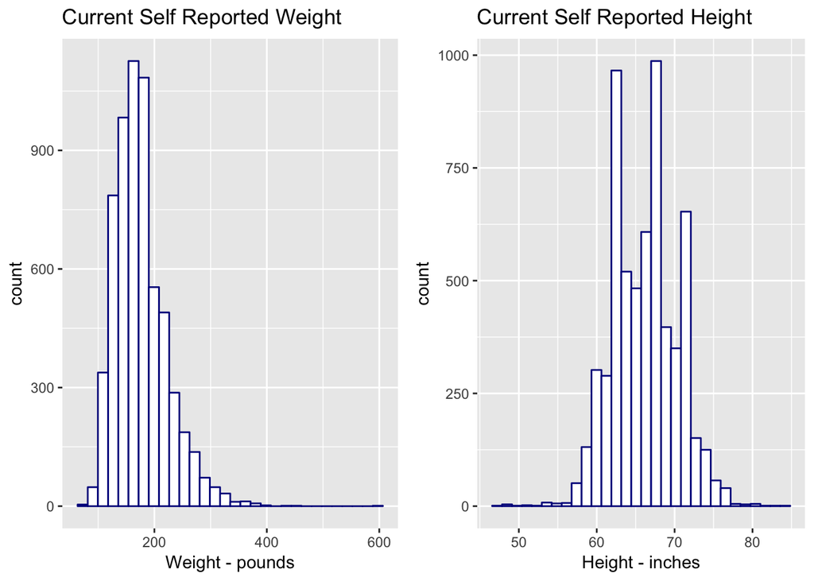

```r
# Current Self Reported Weight Histogram
CurrentSelfReportedWeight_hist <- ggplot(data = weight_df, aes(x = as.numeric(CurrentSelfReportedWeight_pounds))) +
  geom_histogram(color = 'darkblue', fill = 'white', bins = 30) +
  ggtitle("Current Self Reported Weight") + xlab("Weight - pounds") +
  aes(fill = AC_BMI_Classification)

# Current Self Reported Height Histogram
CurrentSelfReportedHeight_hist <- ggplot(data = weight_df, aes(x = as.numeric(CurrentSelfReportedHeight_inches))) +
  geom_histogram(color = 'darkblue', fill = 'white', bins = 30) +
  ggtitle("Current Self Reported Height") + xlab("Height - inches") +
  aes(fill = AC_BMI_Classification)

grid.arrange(CurrentSelfReportedWeight_hist, CurrentSelfReportedHeight_hist, ncol = 2)
```

- The self reported weight histogram shows a distribution skewed to the right. That means that there are some outliers of people who far excede the mean weight. This skewed distribution does seem to reflect the United States because it one of the most obese (heaviest) nations in the world.
- The self reported height is not skewed to the right; however, there are some abnormally peaks in the histogram. This may be due to people rounding their height. This could be from people rounding their heights when they are unsure. One would expect the height to be normally distributed if the heights were measured by a scientist or doctor rather than a questionnaire

## (Quick Aside) Normalizing Skewed Data

Oftentimes, skewed data is normalized for the purposes of modeling. To demonstrate, the weight data will be normalized via a log transformation

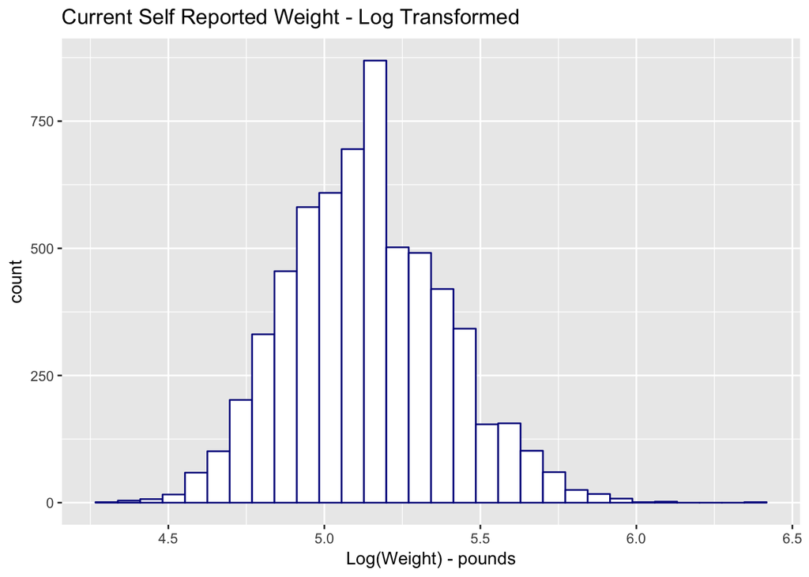

```r
ggplot(data = weight_df, aes(x = log(as.numeric(CurrentSelfReportedWeight_pounds)))) +
  geom_histogram(color = 'darkblue', fill = 'white', bins = 30) +
  ggtitle("Current Self Reported Weight - Log Transformed") +
  xlab("Log(Weight) - pounds")
```

## Add Function to Calculate BMI

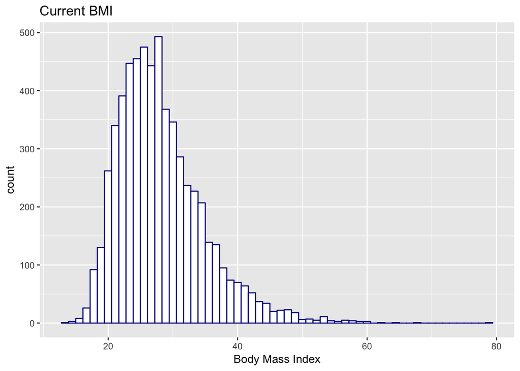

```r
calc_BMI <- function(weight, height)
{
  if(is.na(weight) | is.na(height))
  {
    return(NaN)
  }
  else if((weight != "Don't Know" & weight != "Refused") &
          (height != "Don't Know" & height != "Refused"))
  {
    return(as.numeric(weight) / (as.numeric(height) ** 2) * 703)
  }
  else
    return(NaN)
}

weight_df$AC_CurrentBMI <- mapply(calc_BMI, weight_df$CurrentSelfReportedWeight_pounds, weight_df$CurrentSelfReportedHeight_inches)

# Current BMI Histogram
ggplot(data = weight_df, aes(x = as.numeric(AC_CurrentBMI), )) +
  geom_histogram(color = 'darkblue', fill = 'white',bins = 60) +
  ggtitle("Current BMI") +
  xlab("Body Mass Index")
```

– Unsurpsingly, the BMI distribution is skewed to the right. This is because height is roughly normally distributed while weight is skewed to the right.

## Add Categorical Variable AC_BMI_Classification

This BMI classification is pulled from the American Cancer Society (https://www.cancer.org/cancer/cancer-causes/diet-physical-activity/body-weight-and-cancer-risk/adult-bmi.html)

- This categorical variable will be useful in splitting up the data set and coloring the plots to give more context.
- The histograms for weight and height will be colored with AC_BMI_Classification

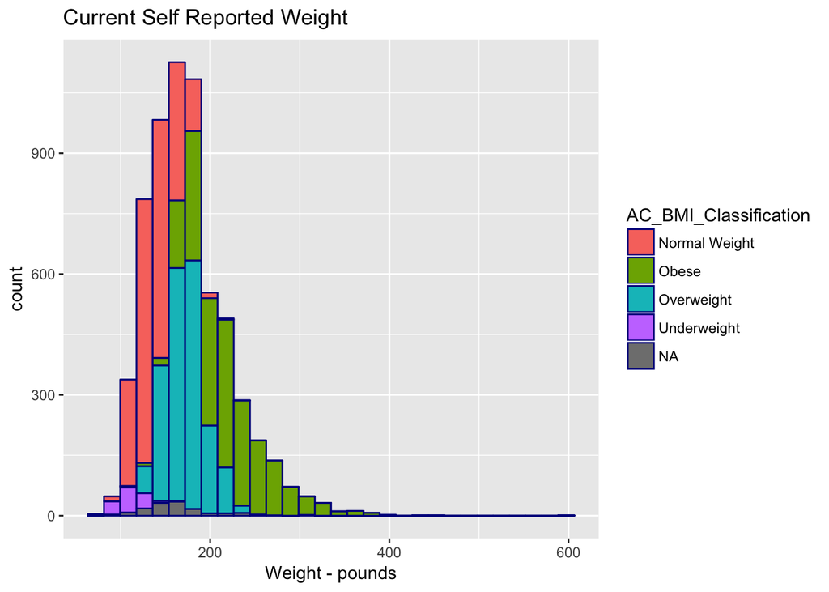

```r
# Add column to classify people's self reported weight (for graph coloring)
weight_df$AC_BMI_Classification[as.numeric(weight_df$AC_CurrentBMI) < 18.5] <- "Underweight"

weight_df$AC_BMI_Classification[as.numeric(weight_df$AC_CurrentBMI) > 18.5
                         & as.numeric(weight_df$AC_CurrentBMI) < 25 ] <- "Normal Weight"

weight_df$AC_BMI_Classification[as.numeric(weight_df$AC_CurrentBMI) > 25
                         & as.numeric(weight_df$AC_CurrentBMI) < 30 ] <- "Overweight"

weight_df$AC_BMI_Classification[as.numeric(weight_df$AC_CurrentBMI) > 30] <- "Obese"

# Current Self Reported Weight Histogram - with BMI Classification
ggplot(data = weight_df, aes(x = as.numeric(CurrentSelfReportedWeight_pounds))) +
  geom_histogram(color = 'darkblue', bins = 30) +
  ggtitle("Current Self Reported Weight") +
  xlab("Weight - pounds") +
  aes(fill = AC_BMI_Classification)
```

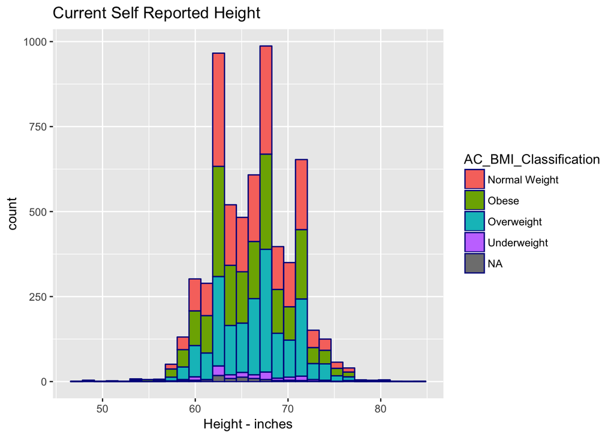

```r
# Current Self Reported Height Histogram - with BMI Classification
ggplot(data = weight_df, aes(x = as.numeric(CurrentSelfReportedHeight_inches))) +
  geom_histogram(color = 'darkblue', bins = 30) +
  ggtitle("Current Self Reported Height") +
  xlab("Height - inches") +
  aes(fill = AC_BMI_Classification)
```

## Correlation Calculations for Height and Weight on BMI

```r
# Correlation Calculations
cor(as.numeric(weight_df$CurrentSelfReportedWeight_pounds), as.numeric(weight_df$AC_CurrentBMI),
    use = "complete.obs")
```

```
## [1] 0.868958
```

```r
cor(as.numeric(weight_df$CurrentSelfReportedHeight_inches), as.numeric(weight_df$AC_CurrentBMI),
    use = "complete.obs")
```

```
## [1] -0.04305333
```

- Intuitively, it makes sense that height is not correlated with BMI/BMI_Classification (-0.04305333), while weight is (0.868958).

## Exploratory Visuals for People’s Weight Mindset and Goals

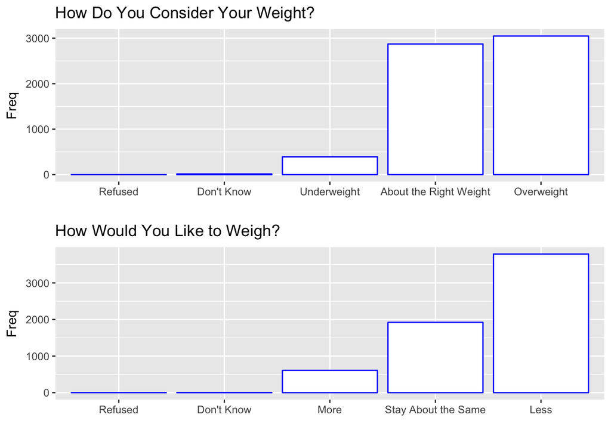

```r
# How Do you Consider Your Weight? Bar Plot
HowDoYouConsiderYourWeight_df <- data.frame(sort(table(weight_df$HowDoYouConsiderYourWeight)))

HowDoYouConsiderYourWeight_bp <- ggplot(data = HowDoYouConsiderYourWeight_df, aes(x = Var1, y = Freq)) +
  geom_bar(stat = "identity", color = 'blue', fill = 'white') +
  ggtitle("How Do You Consider Your Weight?") +
  xlab("")

# How Would You Like to Weight? Bar Plot
HowWouldYouLikeToWeigh_df <- data.frame(sort(table(weight_df$HowWouldYouLikeToWeigh)))

HowWouldYouLikeToWeigh_bp <- ggplot(data = HowWouldYouLikeToWeigh_df, aes(x = Var1, y = Freq)) +
  geom_bar(stat = "identity", color = 'blue', fill = 'white') +
  ggtitle("How Would You Like to Weigh?") +
  xlab("")

# Side by side comparison
grid.arrange(HowDoYouConsiderYourWeight_bp, HowWouldYouLikeToWeigh_bp, nrow = 2)
```

- Overall, a vast majority of people would prefer to lose weight or stay the same weight.
- Still, there appears to be some cognitive dissonance: There are far more people who want to weigh less compared to how many people considered themselves overweight. This could be due to people having a biased view of what is considered healthy weight. Social media and entertainment are highly influential in influencing people to want to look skinny even though they may rationally know that such bodies are not realistic.

## Export Dataframe to csv

```r
write_csv(weight_df, "clean_weight_df.csv")
```

- This step allows us to import the data into Tableau

## BMI Histogram for Different Weight Goals (Tableau)

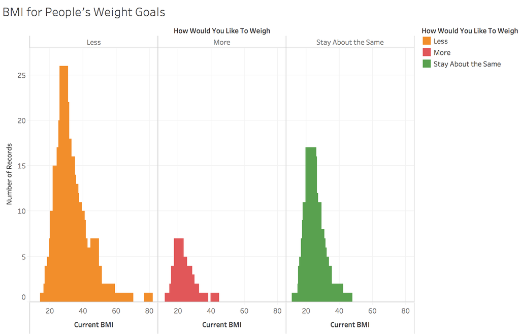

```r
# Use sqldf to calculate mean BMI for groups in HowWouldYouLikeToWeigh
sqldf("select HowWouldYouLikeToWeigh,avg(AC_CurrentBMI) from weight_df group by HowWouldYouLikeToWeigh")
```

```
##   HowWouldYouLikeToWeigh avg(AC_CurrentBMI)
## 1             Don't Know           21.17162
## 2                   Less           31.02378
## 3                   More           22.09936
## 4                Refused                 NA
## 5    Stay About the Same           24.48412
```

## Analysis on Methods Used to Lose Weight

```r
# TriedToLoseWeightInPastYear: table
sort(table(weight_df$TriedToLoseWeightInPastYear))
```

```
##
##    Refused Don't Know        Yes         No
##          1          3       2116       3392
```

```r
# Percentage of people who tried to lose weight in the last year
2116 / nrow(weight_df)
```

```
## [1] 0.3344397
```

```r
# Counts what methods people used to try to lose weight
TLW_counts_list <- lapply(weight_df[9:29],function(x) length(which(!is.na(x))))
TLW_counts_df <- data.frame(unlist(TLW_counts_list))
TLW_counts_df$type_of_weightloss_method <- rownames(TLW_counts_df)
rownames(TLW_counts_df) <- NULL

# Use dplyr select to reorder and rename columns
TLW_counts_df %<>% select(type_of_weightloss_method, unlist.TLW_counts_list.) %>%
  rename(count = unlist.TLW_counts_list.) %>%
  arrange(desc(count))
TLW_counts_df
```

```
##          type_of_weightloss_method count
## 1                    Exercised_TLW  1888
## 2                      AteLess_TLW  1756
## 3      AteMoreFruitsVegsSalads_TLW  1638
## 4             DrankLotsOfWater_TLW  1579
## 5              AteLessJunkfood_TLW  1335
## 6                AteLessSweets_TLW  1178
## 7          ChangedEatingHabits_TLW  1177
## 8                   AteLessFat_TLW   945
## 9  SwitchedFoodToLowerCalories_TLW   940
## 10               AteFewerCarbs_TLW   818
## 11                SkippedMeals_TLW   570
## 12      AteDietFoodsOrProducts_TLW   266
## 13        NonprescriptionPills_TLW   196
## 14                  LiquidDiet_TLW   150
## 15                 SpecialDiet_TLW   150
## 16           WeightLossProgram_TLW    99
## 17       PrescriptionDietPills_TLW    93
## 18                      Smoked_TLW    44
## 19      TookLaxativesOrVomited_TLW    37
## 20                       Other_TLW    30
## 21        HadWeightLossSurgery_TLW    16
```

- The standard recommended procedures from most health professionals are at the top of the most frequent methods used to lose weight. Other more extreme methods such as surgery, pills, smoking, and vomitting are far less common.

## Calculates how many methods to lose weight were used for each respondent

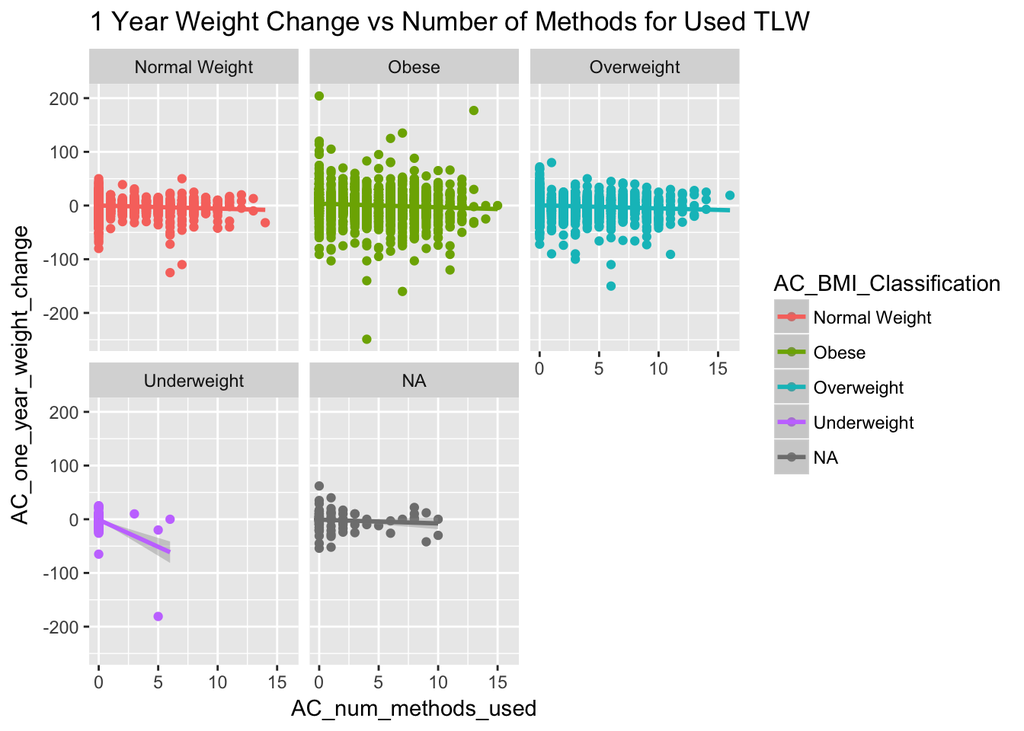

```r
weight_df$AC_num_methods_used <- apply(weight_df[9:29], MARGIN = 1, FUN = function(x) length(which(!is.na(x))))

# One year weight change
weight_df$AC_one_year_weight_change <- as.numeric(weight_df$CurrentSelfReportedWeight_pounds) -
  as.numeric(weight_df$SelfReportedWeight1YearAgo)

# Ten year weight change
weight_df$AC_ten_year_weight_change <- as.numeric(weight_df$CurrentSelfReportedWeight_pounds) -
  as.numeric(weight_df$SelfReportedWeight10YearsAgo)

# Plot of 1 year weight changes vs num_methods_used for weight loss
ggplot(data = weight_df, aes(x = AC_num_methods_used, y = AC_one_year_weight_change)) +
  geom_point() +
  aes(color = AC_BMI_Classification) +
  facet_wrap(~AC_BMI_Classification) +
  geom_smooth(method='lm',formula=y~x) +
  ggtitle("1 Year Weight Change vs Number of Methods for Used TLW")
```

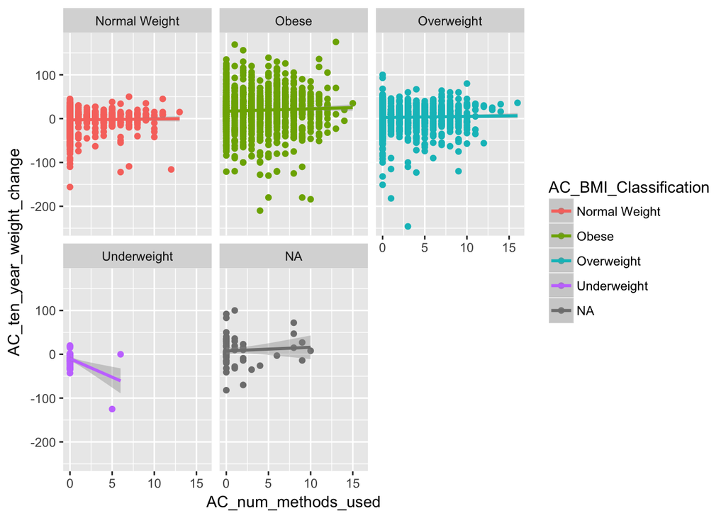

```r
# Plot of 10 year weight changes vs num_methods_used for weight loss
ggplot(data = weight_df, aes(x = AC_num_methods_used, y = AC_ten_year_weight_change)) +
  geom_point() +
  aes(color = AC_BMI_Classification) +
  facet_wrap(~AC_BMI_Classification) +
  geom_smooth(method='lm',formula=y~x)
```

```r
cor(weight_df$AC_one_year_weight_change, weight_df$AC_num_methods_used, use = "complete.obs")
```

```
## [1] -0.08560996
```

```r
cor(weight_df$AC_ten_year_weight_change, weight_df$AC_num_methods_used, use = "complete.obs")
```

```
## [1] 0.1286365
```

- The number of methods used to lose weight has almost no bearing on weight loss for a one and ten year time frame. This is a testament to how difficult it is to lose weight. Furthermore, the respondents could have not stuck with any of the plans for a significant amount of time.
- There are some differences between a 1 and 10 year time frame. The shorter term has more negative correlations for weight change and number of methods used, while the longer 10 year time frame has mostly positive correlations.